# Assignment 1 R Notebook

Rex Harvilla

## The Data

The data was extracted from the 1974 Motor Trend US magazine, and comprises fuel consumption and 10 aspects of automobile design and performance for 32 automobiles (1973–74 models). The 10 data points given are: Miles Per Gallon, Number of Cylinders (4,6,8), Engine Displacement, Gross Horsepower, Rear Axle Gear Ratio, Weight (in 1000lbs), 1/4 Mile Acceleration Time, Engine Configuraton (V=1, Straight=0), Transmission (0=automatic,1=manual), Number of Forward Gears (3,4,5), Number of Carborators.

## Research Question

1. Is there a direct relationship between the number of cylinders a car has and its horsepower?
2. What is the relationship between the weight of a car and its miles per gallon?

# Plots

```
ggplot(data = mtcars, mapping = aes(x=cyl,y=hp , group = cyl)) +
  geom_boxplot()
```

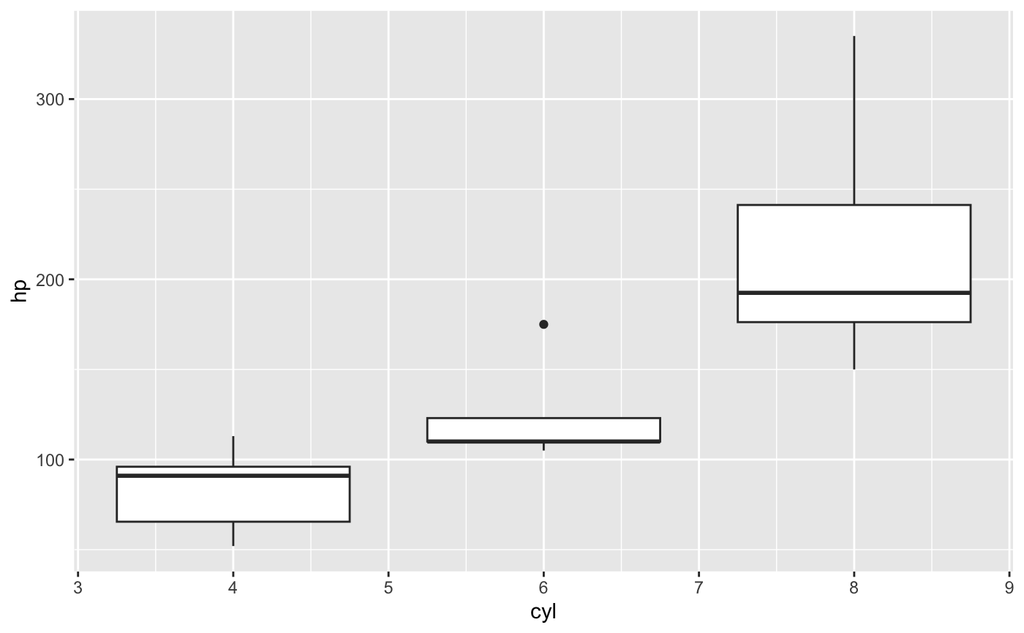

```
ggplot(data = mtcars,
        mapping = aes(x=wt , y=mpg)) +
  geom_point() +
  geom_smooth(method = "lm")
```

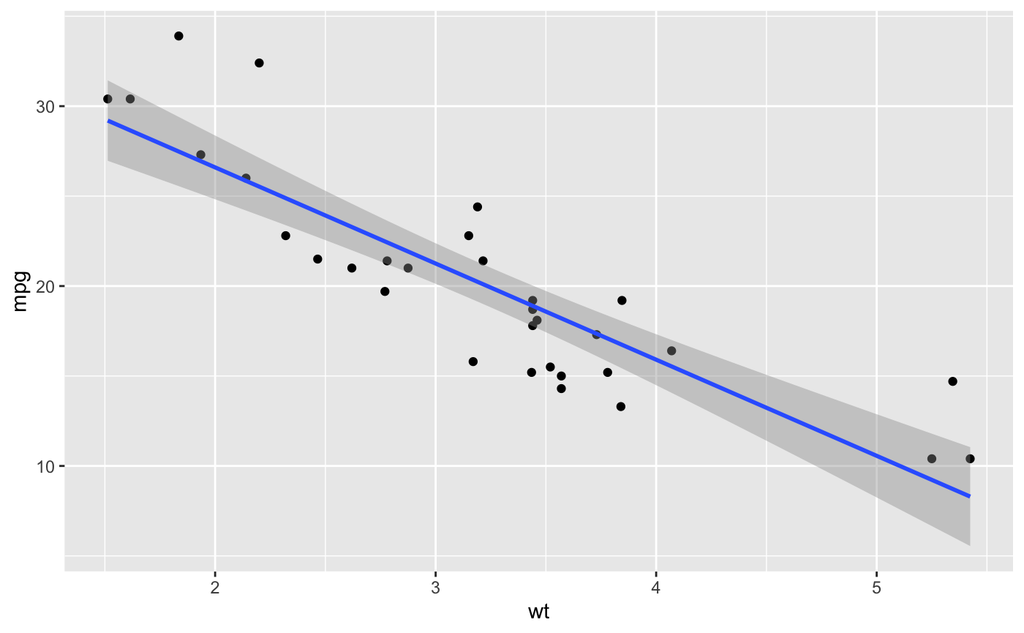

#Conclusion We can see from the first graph that the more cylinders a car has, the higher its horsepower, demonstrating a positive correlation between the two data points. For the second graph, we see a negative correlation between the cars weight and its miles per gallon, showing that the more a car weighs, the less fuel efficient (miles per gallon) it is.